# 商业分析作业之一：洞悉S曲线

#### $$张博 2018211243 集成电路工程$$

## 作业内容

作为技术上的后发国家，市场需求的成长，对产业的竞争态势有重要的影响，进而会影响企业的行为及其绩效、甚至成败。那么，中国市场需求的成长有什么特点，将如何影响的动向以及产业中企业的产业的行为？

在绝大部分的行业，产业中市场的销售数量都呈现一个**S型的曲线**，这个S曲线所展示的市场需求发展过程是企业运营和可持续发展需要面对的环境。市场需求的成长有许多的观察的角度，其中之一是从产业中对特定类型产品（产品品类）的用户增加的角度来考察，这一视角的特点是，从创新采用者（用户）行为的角度，推演市场中供给者需要面对的市场需求状况，进一步结合行业中的竞争角度，就能对企业的战略有重要的启发。这一理论也是创新管理的重要的基础理论之一。

本次作业希望学生从**已经完整创新扩散历史的产品的数据**，去解析市场中需求的发展和变化。我们这里说的需求，包括市场中**客户的类型、数量、需求多样性以及成长速度**四个维度。作业过程中需要参考相关的创新扩散理论，结合中国企业用户的行为特征作出合理的解释，借助统计分析工具进行。同时需要结合产业中的重要事件和现象，进行检验和猜测。

请选择一个产品品类，从公开资料中找到其销量的数据，运用课堂的知识，结合已有的理论，从中解析出用户类型、数量和结构的变化。

自由选择行业（产品品类），要求已有完整的扩散历史，通过二手资料，找到历史的销售数据。借鉴创新扩散理论，结合已有的模型（可以在适当条件下对模型进行修正），解析出这个市场中用户需求的历史变化，并给出关键的时间点。

## 智能手机市场的发展变化-摘要

- 本次作业选择智能手机在中国市场的扩散作为历史作为研究案例。研究智能手机从诞生到发展经历的生命周期。本工作对智能手机历年相关数据进行分析，结合创新扩散理论对分析结果做出一定的解释，同时得到对未来市场的相关预测。
- 经过对智能手机用户量的分析发现，实际正在被使用的智能手机数量可以很好地利用bass模型拟合。曲线程s型，存在最大市场容量。。而智能手机的出厂销售量不满足bass模型，本文对此进行重新建模，模型很好地拟合了实际数据。研究发现，由于智能手机在长期看来不属于严格意义的耐用品。**智能手机的累积用户虽然存在饱和，但是智能手机的累积销量并不存在饱和**。

## 数据准备

### 1.选择智能手机市场的原因

1. 智能手机的诞生在功能和结构上颠覆了传统移动手机，几乎彻底改变了人们的生活结构和沟通方式，属于很典型的创新产品
2. 未来几年通讯技术快速发展，网络模式从原来的2G改进到3G和4G，一直到即将普及的5G技术。这刺激了智能手机结构和功能的不断创新
3. 通信技术的变革对智能手机市场的变化产生巨大影响，即将到来的5G技术将会如何影响智能手机的市场变化是一个有趣的课题，同时通过通信技术的变革分析智能手机的市场变化也是很好的切入点

### 2. 采集的数据与采集原因

由于没能找到完全符合要求的智能手机市场销售数据。因此选用一定的类似数据经过合理处理后作为智能手机市场数据的表征，主要考虑以下几点：

1. 数据1:3G手机和4G手机出货量. 由于智能手机在中国市场的推广阶段恰好处于3G通信技术的普及阶段。几乎所有的智能手机都是3G手机或者4G手机。因此利用3G手机和4G手机的出货量可以很好的表征智能手机的出货量。而手机的出货量又可以近似表征手机的市场需求。

$$ \mbox{智能手机销量} \propto 智能手机出货量 \approx 3G手机出货量+4G手机出货量$$

1. 数据2:中国电信运营商3G用户和4G用户注册数. 由于智能手机属于一定时间（1-3年）内的耐用品。本作业的研究范围超过5年，用户会出现复购现象。为了更好的探索智能手机市场中新用户的扩散与老用户的复购现象。需要尽可能精确的预测智能手机的复购率。因此采用中国电信运营商的注册用户数来估计实际被使用的手机数量，从而分析得出与智能手机复购的相关参数。

$$ \mbox{智能手机用户数} \propto 3G号码注册数 + 4G号码注册数$$

## 数据处理

### 1.数据读取

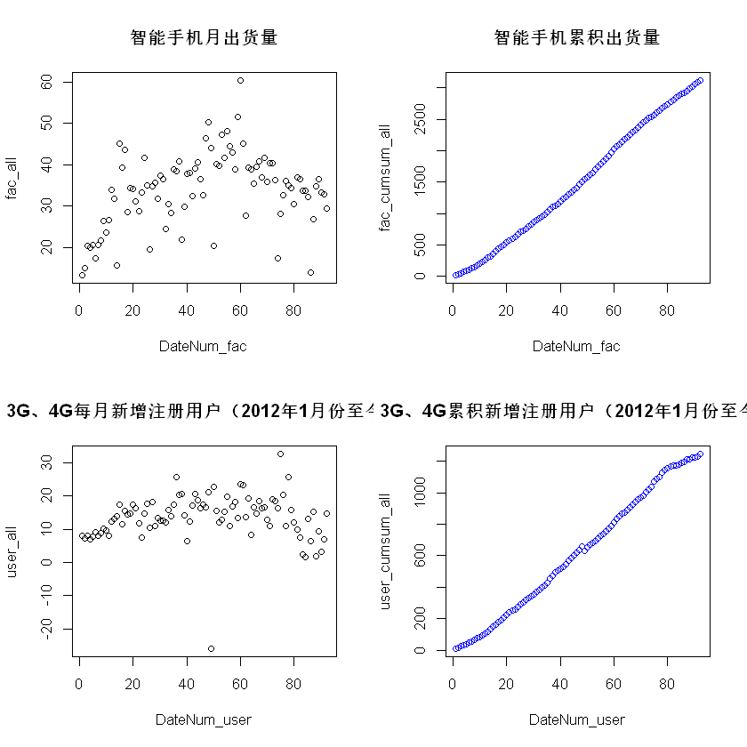

```r
#读取并展示部分数据
myfac_data<-read.csv("data_mobil_factory.csv")
myuser_data <- read.csv("data_mobil_user.csv")
#colnames(myfac_data)
#colnames(myuser_data)

#3G、4G手机出货量 /百万部
Date_fac <-myfac_data$rate  #日期数据
DateNum_fac <- myfac_data$number #日期编号
fac_3G <- myfac_data$X3G #3G 手机月出货量
fac_4G <- myfac_data$X4G #4G 手机月出货量
fac_all <- myfac_data$all #智能手机月出货量
fac_cumsum_all = cumsum(fac_all) # 智能手机累计出货量
par(mfrow=c(2,2))
plot(DateNum_fac,fac_all,main="智能手机月出货量")  # 智能手机月出货量示意图
plot(DateNum_fac,fac_cumsum_all,main="智能手机累积出货量",col="blue")  # 智能手机累积出货量示意图
#plot(DateNum_fac,fac_cumsum_all) # 示意图

#length(fac_all)
#length(fac_cumsum_all)

# 中国电信运营商3G 4G用户注册数 /百万户
Date_user <-myuser_data$rate  #日期数据
DateNum_user <- myuser_data$number #日期编号
user_3G <- myuser_data$X3G_user #3G 注册用户月增加量
user_4G <- myuser_data$X4G_user #4G 注册用户月增加量
user_all <- myuser_data$all_user #3G、4G注册用户月增加量
user_cumsum_all <- cumsum(user_all)

#length(user_cumsum_all)
#length(user_all)

plot(DateNum_user,user_all,main="3G、4G每月新增注册用户（2012年1月份至今）")  # 智能手机累积注册用户
plot(DateNum_user,user_cumsum_all,main="3G、4G累积新增注册用户（2012年1月份至今）",col="blue")  # 智能手机累积注册用户
#lines(DateNum_fac,fac_cumsum_all,main="智能手机累积出货量")  # 智能手机累积出货量示意图
```

### 2.模型假设和数据预处理

1. 假设平均每个手机种放置1.5个注册SIM卡。则实际在使用的智能手机数： $$N_{real\_user} = 电信用户注册数/1.5$$
2. 每月新增智能手机数： $$n_{real\_user}(t) = N_{real\_user}(t)-N_{real\_user}(t-1)$$
3. 由于存在复购现象，实际上的每月手机销量远大于$n_{real\_user}(t)$. 假设手机复购率为$r$，则每月复购的手机数为$r*N_{rean\_user}$. 同时由于存在最小出厂量，每月手机出厂量应该大于某个最小出厂量数值$n_{min}$ 因此实际的每月手机出厂量$n_{phone}(t)$可以由下面的公式表示： $$ n_{phone}(t) = n_{real\_user}(t) + r*N_{rean\_user} + n_{min}$$
4. 本模型忽略其他因素影响。

```r
n_real_user = user_all/1.5        #每月新增智能手机数
N_real_user = user_cumsum_all/1.5 #实际使用的智能手机数
```

### 3.利用Bass模型拟合实际在使用智能手机数量

1. 虽然智能手机本身存在复购现象，但是实际正在使用的智能手机数量可以被归类于耐用品。其原因是用户购买新手机后一般会将原手机搁置。因此，利用Bass模型拟合实际在使用的智能手机数是合理的。

```r
# 拟合
l <- length(n_real_user)
T <- DateNum_user
bassf <- function(x,theta) theta[1] * ( ((theta[2]+theta[3])^2 / theta[2]) * exp(-(theta[2]+theta[3])* x) ) /(1+(theta[3]/theta[2])*exp(-(theta[2]+theta[3])*x))^2
fitnessL <- function(theta,x,y) -sum((y-bassf(x,theta))^2)
library(GA)
GA3 <- ga(type="real-valued", fitness=fitnessL, x=T, y=n_real_user, lower=c(0,0,0), upper=c(10000,1,1), popSize=1000,crossover=gareal_blxCrossover,maxiter=1000,run=200,names=c("m","p","q"))
summary(GA3)
```

```
-- Genetic Algorithm -------------------

GA settings:
Type                  =  real-valued
Population size       =  1000
Number of generations =  1000
Elitism               =  50
Crossover probability =  0.8
Mutation probability  =  0.1
Search domain =
          m p q
lower     0 0 0
upper 10000 1 1

GA results:
Iterations             = 1000
Fitness function value = -1678.663
Solution =
          m          p          q
[1,] 1067.5 0.00526042 0.02957726
```

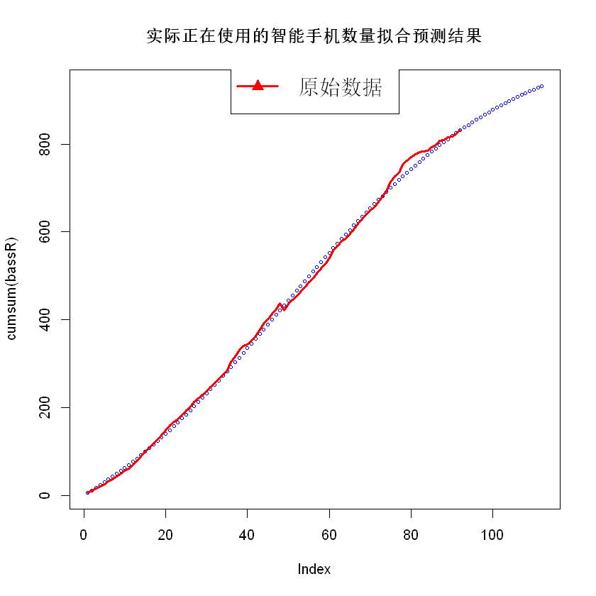

```r
#绘图
#plot(Rate)
T <- 1:(l+20)
bassR <- bassf( T,c(1052.69 ,0.005192533 ,0.03051466))
#plot(bassR)
fit_N_real_user = cumsum(bassR)
#plot(fitnessL(c(199.977,5.251169e-05,0.006172433),T,Rate ) )

plot(cumsum(bassR),cex=0.5,lty=1,col="blue",main="实际正在使用的智能手机数量拟合预测结果")
lines(DateNum_user,N_real_user,cex=1.5,pch=17,col="red",lwd=3)
legend("bottom",inset=0.9,title="",c("原始数据"),cex=1.5,pch=17,col="red",lwd=3)
```

上图拟合并预测了实际正在被使用的智能手机数量

可以看出实际正在被使用的智能手机数量可以很好地利用bass模型拟合。曲线程s型，存在最大市场容量。

### 4.利用遗传算法拟合复购率和最小出厂量

利用公式： $$ n_{phone}(t) = n_{real\_user}(t) + r*N_{rean\_user} + n_{min}$$

```r
T2 <- 1:(l+20)
bassR2 <- bassf( T2,c(1052.69 ,0.005192533 ,0.03051466))
fit_N_real_user = cumsum(bassR2) + 128.424 #拟合的实际正在使用的用户数
#目标：fac_all
# 拟合
l <- length(n_real_user)
T <- DateNum_user
bassf2 <- function(x,theta) bassR2[x]+theta[1]*fit_N_real_user[x]+theta[2]
fitnessL2 <- function(theta,x,y) -sum((y-bassf2(x,theta))^2)
library(GA)
GA3 <- ga(type="real-valued", fitness=fitnessL2, x=T, y=fac_all, lower=c(0,0), upper=c(1000,1000), popSize=1000,crossover=gareal_blxCrossover,maxiter=1000,run=200,names=c("r","n_min"))
summary(GA3)
```

```
-- Genetic Algorithm -------------------

GA settings:
Type                  =  real-valued
Population size       =  1000
Number of generations =  1000
Elitism               =  50
Crossover probability =  0.8
Mutation probability  =  0.1
Search domain =
         r n_min
lower    0     0
upper 1000  1000

GA results:
Iterations             = 1000
Fitness function value = -5389.581
Solution =
               r    n_min
[1,] 0.009509187 19.75379
```

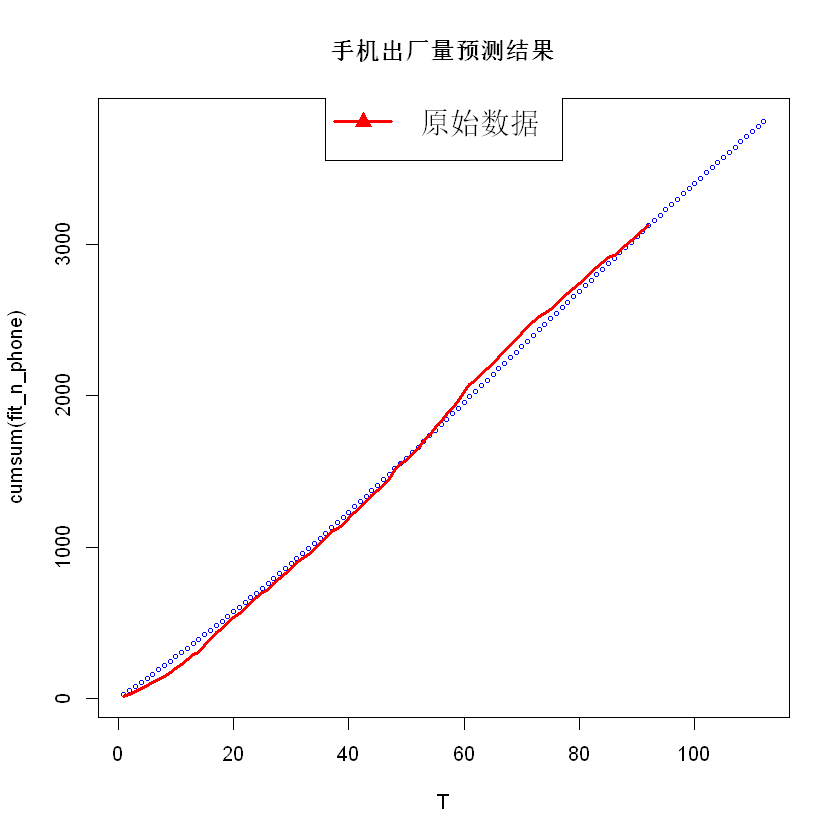

```r
#绘图
T <- 1:(l+20)
fit_n_phone = bassf2(T,c( 0.009567365 ,19.72113))
plot(T,cumsum(fit_n_phone),cex=0.5,lty=1,col="blue",main="手机出厂量预测结果")
lines(DateNum_user,fac_cumsum_all ,cex=1.5,pch=17,col="red",lwd=3)
legend("bottom",inset=0.9,title="",c("原始数据"),cex=1.5,pch=17,col="red",lwd=3)
```

虽然正在使用的智能手机数量满足bass模型理论，呈s曲线型。

但实际智能手机的出厂量短时间内并不满足s型。这是由于智能手机快速更新迭代以及用户复购造成的。使用智能手机的累积用户虽然存在饱和，但是智能手机的累积销量并不存在饱和。

## 工作不足和未来展望

- 由于时间原因，很多工作不够完善
- 暂时没有考虑模型检验，后期工作可以采用前半段数据做拟合，利用后半段数据验证模型正确性，这部部分工作暂时没做。
- 3G和4G单独的数据本身就有很多可以研究的信息，在数据中3G的用户使用量程双边s曲线形，这是由于4G的出现导致的。这一现象可以很好地预测未来5G普及商用时4G用户的演变。
- 数据中存在一段波动是由于3G-4G技术变革时引起的。本文没有做详细解释。
- 没有仔细验证结果的正确定。

## 参考文献

[1] Bass, F. M. 1969. A new product growth model for consumer durables. Management Science 15 (January): 215-27.

[2] 蔡许许，2014，新产品市场起飞的关键规模研究：以中国耐用品市场为例，清华大学硕士学位论文，清华大学

[3] 葡萄酒s曲线案例https://mp.weixin.qq.com/s/E17ydHXfjhTtfC7mmXQjRQ

## 附录

### 原始数据

| date | number | 3G_user | 4G_user | all_user | 3G_fac_each_month | 4G_fac_month | all_fac_month | base_3G_user |
| --- | --- | --- | --- | --- | --- | --- | --- | --- |
| 01/2012 | 1 | 8.176 |  | 8.176 | 13.35 |  | 13.345 | 128.424 |
| 02/2012 | 2 | 7.319 |  | 7.319 | 15.03 |  | 15.034 |  |
| 03/2012 | 3 | 8.141 |  | 8.141 | 20.35 |  | 20.35 |  |
| 04/2012 | 4 | 6.911 |  | 6.911 | 19.98 |  | 19.984 |  |
| 05/2012 | 5 | 7.704 |  | 7.704 | 20.64 |  | 20.64 |  |
| 06/2012 | 6 | 9.078 |  | 9.078 | 17.52 |  | 17.521 |  |
| 07/2012 | 7 | 8.008 |  | 8.008 | 20.69 |  | 20.694 |  |
| 08/2012 | 8 | 8.796 |  | 8.796 | 21.65 |  | 21.645 |  |
| 09/2012 | 9 | 10.082 |  | 10.082 | 26.55 |  | 26.548 |  |
| 10/2012 | 10 | 9.776 |  | 9.776 | 23.66 |  | 23.66 |  |
| 11/2012 | 11 | 8.071 |  | 8.071 | 26.62 |  | 26.615 |  |
| 12/2012 | 12 | 12.317 |  | 12.317 | 34.01 |  | 34.008 |  |
| 01/2013 | 13 | 13.077 |  | 13.077 | 31.91 |  | 31.906 |  |
| 02/2013 | 14 | 14.036 |  | 14.036 | 15.8 |  | 15.795 |  |
| 03/2013 | 15 | 17.351 |  | 17.351 | 45.08 |  | 45.075 |  |
| 04/2013 | 16 | 11.476 |  | 11.476 | 39.35 |  | 39.351 |  |
| 05/2013 | 17 | 15.63 |  | 15.63 | 43.55 |  | 43.552 |  |
| 06/2013 | 18 | 14.497 |  | 14.497 | 28.51 |  | 28.51 |  |
| 07/2013 | 19 | 14.869 |  | 14.869 | 34.47 |  | 34.474 |  |
| 08/2013 | 20 | 17.551 |  | 17.551 | 34.12 |  | 34.122 |  |
| 09/2013 | 21 | 16.308 |  | 16.308 | 31.13 |  | 31.132 |  |
| 10/2013 | 22 | 11.808 |  | 11.808 | 28.75 |  | 28.75 |  |
| 11/2013 | 23 | 7.472 |  | 7.472 | 33.24 |  | 33.243 |  |
| 12/2013 | 24 | 14.733 |  | 14.733 | 41.46 | 0.31 | 41.764 |  |
| 01/2014 | 25 | 17.627 |  | 17.627 | 30.98 | 4.05 | 35.034 |  |
| 02/2014 | 26 | 10.548 |  | 10.548 | 17.96 | 1.59 | 19.552 |  |
| 03/2014 | 27 | 15.232 | 3 | 18.232 | 30.69 | 4.09 | 34.786 |  |
| 04/2014 | 28 | 9.177 | 1.8 | 10.977 | 29.1 | 6.63 | 35.723 |  |
| 05/2014 | 29 | 9.87 | 3.5 | 13.37 | 22.62 | 9.27 | 31.882 |  |
| 06/2014 | 30 | 6.704 | 5.9 | 12.604 | 22.66 | 14.77 | 37.426 |  |

[output cut: 62 more lines]